# ESDSWRF Oat-Pea Polyculture Manuscript Analysis

PME

22 May, 2025, 10:11

# Overview

Analysis for the oat-pea polyculture experiment. This experiment compared the performance of oat, pea, and oat-pea in a mix. Performance was measured by yield, biomass, and stability. The experiment was planted on two dates, late April and June 1st, to simulate site-years. The early planting date included a 3-way, oat-pea-flax mixture.

Major questions are:

1. Does the oat-pea mixture yield more per acre than monocrops? This will be assessed by calculating land equivalent ratios.
2. Is the oat-pea mixture more stable across weather patterns than the monocrops? This will be assessed as change in yield across planting dates.
3. Does the addition of flax hinder oat and pea development?

The design is split plot with four blocks. The main plots are planting date with crop mixture as subplots. Therefore, the error structure is `~(1|BLOCK) + (1|BLOCK:PLANTING) + residuals` (error terms for block and planting date within block).

## Load

```r
libs = c(
  'Matrix', # must install manually for some reason
  'multcompView', # also must install manually
  'lme4',
  'car',
  'ggplot2',
  'ggtext',
  'gt',
  'gridExtra',
  'multcomp',
  'emmeans',
  'tidyr',
  'magrittr',
  'here',
  'wesanderson'
)

for (i in libs) {
  if (!require(i, character.only=TRUE)) {
    renv::install(i, prompt=FALSE)
    library(i, character.only=TRUE)
  }
}

renv::snapshot(packages=libs)
```

[output not shown]

[output cut: 62 more lines]

[output not shown]

```r
sapply(libs, function(x) paste(packageVersion(x), collapse='.')) %>%
  c(R=paste(R.Version()[c('major', 'minor')], collapse='.'), .) %>%
  as.matrix %>%
  set_colnames('Version')
```

```
##              Version
## R            "4.4.1"
## Matrix       "1.7.0"
## multcompView "0.1.10"
## lme4         "1.1.35.5"
## car          "3.1.2"
## ggplot2      "3.5.1"
## ggtext       "0.1.2"
## gt           "1.0.0"
## gridExtra    "2.3"
## multcomp     "1.4.26"
## emmeans      "1.10.4"
## tidyr        "1.3.1"
## magrittr     "2.0.3"
## here         "1.0.1"
## wesanderson  "0.3.7"
```

## General Parameters

```r
colors = wes_palette('Darjeeling1', 5)[-3]

prettyplanting = c(early = 'Planting A',
                   late = 'Planting B')

# p_adjust = 'none'  # Fisher's unprotected LSD. Most permissive.
# p_adjust = 'tukey' # emmeans default. Almost as stringent as bonferroni.
p_adjust = 'fdr'   # control false discovery rate - intermediate.
```

```r
in_dir = 'Data'
in_df = 'analysis dataframe.csv'
out_dir = 'Results'

df = here(in_dir, in_df) %>%
  read.csv

names(df) %<>% gsub('DATE', 'PLANTING', .) %>%
  gsub('PLANTING_PLANTING', 'PLANTING_DATE', .)
```

```r
facts = c(
  'YEAR', 'LOCATION', 'SID', 'PLOT', 'REP', 'TREATMENT', 'PLANTING', 'CROP', 'ROW', 'COL',
  'PLANTING_DATE'
)

df[, facts] %<>% lapply(as.factor)
```

## Functions

```r
se = function(x) sd(x)/sqrt(length(x))

make_anova_table = function(x, append_to=NULL) {
  av = x
  resp = attr(av, "heading")[2]
  resp = strsplit(resp, ": ")[[1]][2]


  p_col = grepl('Pr\\(>', colnames(av))
  out = as.data.frame(av[p_col]) # to allow using merge()
  names(out) = resp
  rownames(out) = rownames(av)

  if (!is.null(append_to)) {
    out = merge(append_to,        # robust to different lengths
                out,
                by='row.names',
                all=TRUE)
    rownames(out) = out[, 'Row.names']
    out[, 'Row.names'] = NULL
  }

  return(out)
}

make_anova_table = function(x, append_to=NULL) {
  av = x
  resp = attr(av, "heading")[2]
  resp = strsplit(resp, ": ")[[1]][2]


  p_col = grepl('Pr\\(>', colnames(av))
  out = data.frame(response = resp,
                   predictor = rownames(av),
                   test = colnames(av)[1],
                   stat = av[,1],
                   p_val = av[,p_col])

  if (!is.null(append_to)) {
    out = rbind(append_to,
                out)
  }

  return(out)
}


get_mean_se = function(ff, data) {
  aggregate(ff,
            data=data,
            FUN=function(x) c(MEAN=mean(x),
                              SE=se(x))) %>%
    do.call(data.frame, .)
}

group_Y = function(data, resp, pred, bump=0.05) {
  ff = paste(resp, pred, sep='~') %>%
    formula
  out = aggregate(ff, data=data, function(x) mean(x) + se(x))
  names(out) %<>% gsub(resp, 'Y', .)
  out[, 'Y'] = out[, 'Y'] + bump*max(out[, 'Y'])
  return(out)
}

gg_formatter = function(x) {
  out = x +
    theme_minimal() +
    theme(panel.grid=element_blank(),
          axis.ticks=element_line(color='black', linewidth=0.1),
          axis.ticks.length=unit(0.3, units='mm'),
          legend.position='bottom',
          axis.title.x=element_markdown(),
          axis.title.y=element_markdown())
  return(out)
}

text_sizer = function(x, size=8) {
  require(ggplot2)
  out = x +
    theme(legend.text=element_text(size=size-1),
        strip.text=element_markdown(size=size),
        axis.title=element_markdown(size=size-1),
        axis.text=element_text(size=size-1),
        text=element_text(size=size),
        legend.box.spacing=margin(0.1))
  return(out)
}
```

# QA/QC

Treatments contingency table

```r
with(df, table(CROP, PLANTING))
```

```
##               PLANTING
## CROP           early late
##   oat              4    4
##   oat-pea          4    4
##   oat-pea-flax     4    0
##   pea              4    4
```

Missing values of different measurements.

```r
sapply(df, function(x) sum(is.na(x))) %>%
  .[.>0]
```

```
## FLAX_MATURE_PLANTING      PREDATION_EATEN   PREDATION_NOTEATEN
##                   28                   12                   12
##      BUGVAC_RICHNESS     BUGVAC_ABUNDANCE               OAT_CP
##                   12                   12                    8
##               PEA_CP              OAT_ADF              PEA_ADF
##                    8                    8                    8
##              OAT_NDF              PEA_NDF              OAT_TDN
##                    8                    8                    8
##              PEA_TDN               OAT_ME               PEA_ME
##                    8                    8                    8
##              OAT_NEl              PEA_NEl              OAT_NEg
##                    8                    8                    8
##              PEA_NEg              OAT_NEm              PEA_NEm
##                    8                    8                    8
##               OAT_DE               PEA_DE              OAT_DDM
##                    8                    8                    8
##              PEA_DDM              OAT_DMI              PEA_DMI
##                    8                    8                    8
##              OAT_RFV              PEA_RFV
##                    8                    8
```

Very rough outlier check.

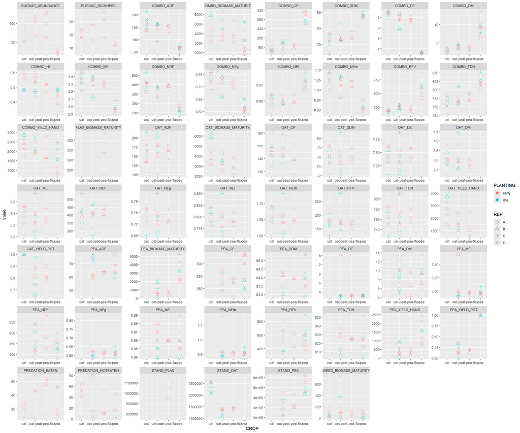

```r
is_data = sapply(df, is.numeric)

tt = cbind(df[, c('CROP', 'PLANTING', 'REP')],
           df[, is_data]) %>%
  pivot_longer(cols=where('is.numeric'))
tt[, 'value'] %<>% sapply(function(x) ifelse(x==0, NA, x))
ggplot(tt,
       aes(x=CROP,
           y=value,
           color=PLANTING,
           shape=REP)) +
  facet_wrap(~name, scales='free') +
  scale_shape_manual(values=1:4) +
  geom_point(size=3)
```

*Outliers*:

- Weed biomass, which is to be expected due to patchiness.That specific part of the field was especially weedy.
- Predation seems bimodal, so tough to analyze.
- Pea harvest index - late planting, oat-pea, replicate A. This is worth investigating/re-measuring.

# Treatment Properties

Stand counts

```r
aggregate(STAND_OAT ~ CROP + PLANTING,
          data=df,
          mean)
```

| CROP | PLANTING | STAND_OAT |
| --- | --- | --- |
| oat | early | 2647638 |
| oat-pea | early | 1400919 |
| oat-pea-flax | early | 1394357 |
| pea | early | 0 |
| oat | late | 2273622 |
| oat-pea | late | 1125328 |
| pea | late | 0 |

```r
aggregate(STAND_PEA ~ CROP + PLANTING, data=df, mean)
```

| CROP | PLANTING | STAND_PEA |
| --- | --- | --- |
| oat | early | 0.0 |
| oat-pea | early | 324803.1 |
| oat-pea-flax | early | 344488.2 |
| pea | early | 561023.6 |
| oat | late | 0.0 |
| oat-pea | late | 275590.6 |
| pea | late | 459317.6 |

```r
aggregate(STAND_FLAX ~ CROP + PLANTING, data=df, mean)
```

| CROP | PLANTING | STAND_FLAX |
| --- | --- | --- |
| oat | early | 0 |
| oat-pea | early | 0 |
| oat-pea-flax | early | 984252 |
| pea | early | 0 |
| oat | late | 0 |
| oat-pea | late | 0 |
| pea | late | 0 |

# Weather

```r
in_wet = 'Jan1thruSept26_2023.csv'

wet = here(in_dir,
           in_wet) %>%
  read.csv

names(wet) = c(
  'YEAR',
  'DOY',
  'DATE',
  'MINT',
  'MAXT',
  'AVGT',
  'PPT')

wet$`NA` = NULL
wet$PPT = wet$PPT * 25.4
wet$DATE %<>% as.Date(format='%m/%d/%Y')

planting_dates = df$PLANTING_DATE %>%
  as.Date(format='%m/%d/%Y') %>%
  unique %>%
  sort %>%
  set_names(c('early', 'late'))

flowering_dates = c(early='2023-06-16',
                    late='2023-07-17') %>%
  as.Date

harvest_dates = c(early='2023-07-17',
                  late='2023-08-22') %>%
  as.Date()

season=c(early='early',
         late='late') %>%
  lapply(function(x) c(planting=planting_dates[[x]],
                       flowering=flowering_dates[[x]],
                       harvest=harvest_dates[[x]]))
```

```r
subset_weather = function(dates, weather) {
  out = subset(weather, DATE >= dates[1] & DATE <= dates[2])
  return(out)
}

GDD = function(low, high, base=0, ceiling=Inf, cumulative=TRUE) {
  x = cbind(low, high)
  x[x<base] = base
  x[x>ceiling] = ceiling

  gdd = (x[,2] + x[,1]) / 2
  gdd = gdd - base

  if (cumulative) gdd = cumsum(gdd)

  return(gdd)
}

get_weather = function(planting=c('early', 'late'), weather) {
  dates = season[[planting]][c('planting', 'harvest')]
  x = subset_weather(dates, weather)

  out = data.frame(
    PLANTING=planting,
    DAP = seq_len(nrow(x)),
    GDD = GDD(x$MINT, x$MAXT, cumulative=TRUE),
    CUM_PPT = cumsum(x$PPT),
    MAXT = x$MAXT
  )
  return(out)
}
```

```r
early = get_weather('early', wet)
late = get_weather('late', wet)

pltdf = rbind(early, late) %>%
  pivot_longer(cols=c('GDD', 'CUM_PPT', 'MAXT'))

pltdf$prettyplanting = pltdf$PLANTING %>%
  as.character %>%
  prettyplanting[.]

prettynames = c(
  CUM_PPT = 'Cumulative<br>Precipitation [mm]',
  MAXT = 'Maximum<br>Temperature [C]',
  GDD = 'Cumulative<br>Growing Degree Days [C]'
)
pltdf$prettynames = prettynames[pltdf$name] %>%
  factor(levels=prettynames)


flower_DAP = lapply(season, function(x) x['flowering']-x['planting'])
flower_DAP = names(flower_DAP) %>%
  lapply(function(x) subset(pltdf, PLANTING==x & DAP==flower_DAP[[x]])) %>%
  do.call(rbind, .)
flower_DAP$NAME = 'Flowering Date'
```

## Plot Fig 1 - Weather

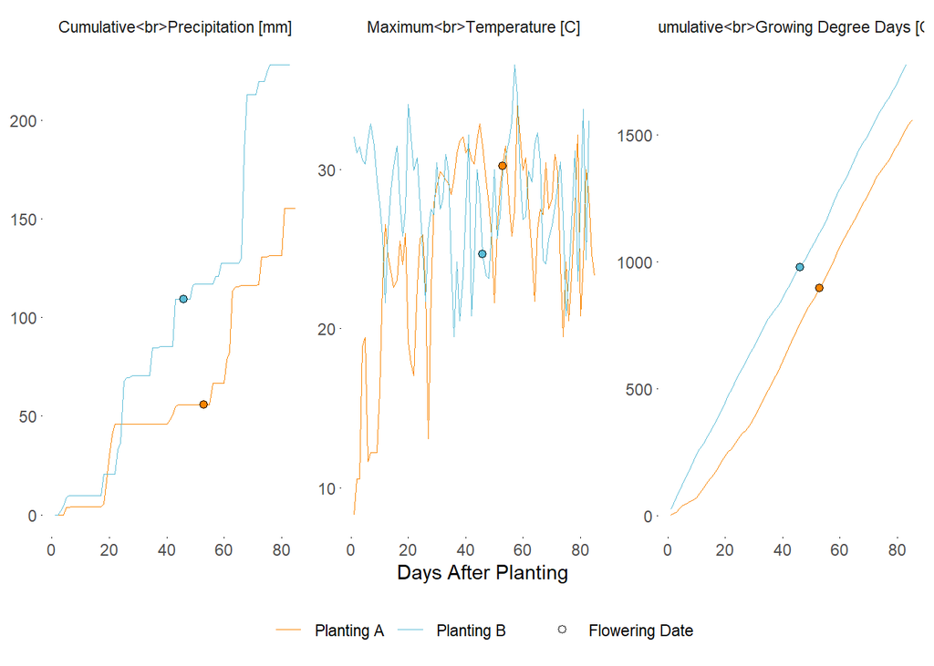

```r
plt = ggplot(pltdf) +
  facet_wrap(~prettynames,
             scales='free_y') +
  scale_color_manual(values=colors[3:4]) +
  # geom_hline(aes(yintercept=0),
  #            color='lightgray',
  #            linewidth=0.05) +
  geom_path(aes(x=DAP,
                y=value,
                color=prettyplanting),
            linewidth=0.2) +
  scale_shape_manual(values=21) +
  scale_fill_manual(values=colors[3:4],
                    guide=NULL) +
  geom_point(data=flower_DAP,
             aes(x=DAP,
                 y=value,
                 fill=prettyplanting,
                 shape=NAME),
             size=2,
             stroke=0.2,
             color='black') +
  labs(x='Days After Planting',
       y=NULL) +
  guides(color=guide_legend(title=NULL, order=1),
         shape=guide_legend(title=NULL, order=2)) +
  theme_minimal() +
  theme(panel.grid=element_blank(),
        axis.ticks=element_line(color='black', linewidth=0.1),
        axis.ticks.length=unit(0.3, units='mm'),
        legend.position='bottom',
        legend.title.position='bottom')

plt
```

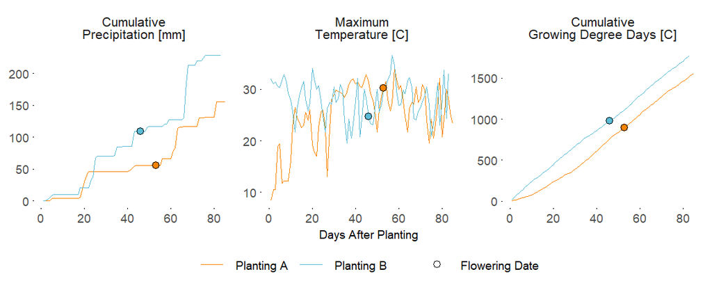

```r
fig1 = text_sizer(plt)
fig1
```

```r
here(out_dir,
     'Figure 1 - Weather.jpeg') %>%
  jpeg(height=2.5, width=6, units='in', res=600)
fig1
dev.off()
```

# Productivity

## Total Yield

The formula is:

```r
resp = 'COMBO_YIELD_HAND'
pred = 'CROP*PLANTING'
err = '(1|REP/PLANTING)'
dd = subset(df, CROP != 'oat-pea-flax')

ff = paste(resp, '~', pred, '+', err) %>%
  formula %T>%
  print
```

```
## COMBO_YIELD_HAND ~ CROP * PLANTING + (1 | REP/PLANTING)
## <environment: 0x0000015545973308>
```

```r
mod = lmer(ff, data=df)
av = Anova(mod, test.statistic='F')
av
```

|  | F | Df | Df.res | Pr(>F) |
| --- | --- | --- | --- | --- |
| CROP | 21.902764 | 3 | 15.020165 | 9.706594e-06 |
| PLANTING | 14.257459 | 1 | 3.378414 | 2.641677e-02 |
| CROP:PLANTING | 3.140584 | 2 | 15.020165 | 7.252362e-02 |

A marginal interaction between crop and planting date. Crop has a main effect, as does planting.

Save into an anova table for the manuscript.

```r
anova_table = make_anova_table(av)
```

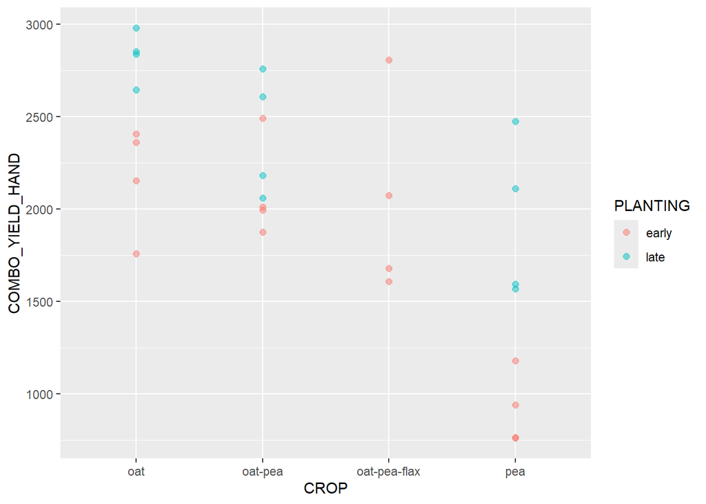

```r
ggplot(df,
       aes(x=CROP,
           y=.data[[resp]],
           color=PLANTING)) +
  geom_point(alpha=0.5,
             size=2)
```

In general, oats yielded better than mixes and peas. The late planting was more productive - especially for the monocultures. For the early planting, the mix seemed as productive as the oat monoculture. Whether flax affected oat-pea yields is uncertain.

Yields were quite poor in all cases. Will need to compare to oat-clover yields.

This suggests that the oat-pea mix is more stable across weather patterns.

```r
emeans = emmeans(mod, ~PLANTING | CROP) %>%
  cld(Letters=letters,
      reverse=TRUE,
      adjust=p_adjust)
emeans
```

|  | PLANTING | CROP | emmean | SE | df | lower.CL | upper.CL | .group |
| --- | --- | --- | --- | --- | --- | --- | --- | --- |
| 1 | late | oat | 2827.2638 | 170.519 | 17.11294 | 2408.3848 | 3246.143 | a |
| 2 | early | oat | 2168.7992 | 170.519 | 17.11294 | 1749.9203 | 2587.678 | b |
| 3 | late | oat-pea | 2401.7388 | 170.519 | 17.11294 | 1982.8599 | 2820.618 | a |
| 4 | early | oat-pea | 2092.1916 | 170.519 | 17.11294 | 1673.3126 | 2511.071 | a |
| 5 | late | oat-pea-flax | NA | NA | NA | NA | NA |  |
| 6 | early | oat-pea-flax | 2041.0105 | 170.519 | 17.11294 | 1681.4277 | 2400.593 | a |
| 7 | late | pea | 1935.8596 | 170.519 | 17.11294 | 1516.9806 | 2354.739 | a |
| 8 | early | pea | 910.5971 | 170.519 | 17.11294 | 491.7182 | 1329.476 | b |

```r
emeans1 = emmeans(mod, ~CROP | PLANTING) %>%
  cld(Letters=LETTERS,
      reverse=TRUE,
      adjust=p_adjust)
emeans1
```

|  | CROP | PLANTING | emmean | SE | df | lower.CL | upper.CL | .group |
| --- | --- | --- | --- | --- | --- | --- | --- | --- |
| 4 | oat | early | 2168.7992 | 170.519 | 17.11294 | 1692.9845 | 2644.614 | A |
| 3 | oat-pea | early | 2092.1916 | 170.519 | 17.11294 | 1616.3769 | 2568.006 | A |
| 2 | oat-pea-flax | early | 2041.0105 | 170.519 | 17.11294 | 1565.1958 | 2516.825 | A |
| 1 | pea | early | 910.5971 | 170.519 | 17.11294 | 434.7824 | 1386.412 | B |
| 8 | oat-pea-flax | late | NA | NA | NA | NA | NA |  |
| 6 | oat | late | 2827.2638 | 170.519 | 17.11294 | 2374.8592 | 3279.668 | A |
| 5 | oat-pea | late | 2401.7388 | 170.519 | 17.11294 | 1949.3343 | 2854.143 | AB |
| 7 | pea | late | 1935.8596 | 170.519 | 17.11294 | 1483.4550 | 2388.264 | B |

```r
colnames(emeans1) %<>% gsub('.group', '.GROUP', .)
```

```r
keep = c('PLANTING', 'CROP', '.group')

has_flax = grepl('flax', emeans$CROP)
emeans[has_flax, '.group'] = ''

emeans %<>%
  .[, keep] %>%
  merge(emeans1)

emeans[, '.group'] = with(emeans,
                          paste0(trimws(.GROUP),
                                 trimws(.group)))
```

### Plot

```r
prettyplanting = c(early = 'Planting A',
                   late = 'Planting B')
grp = 'CROP+PLANTING'



annotate_df = c('CROP', 'PLANTING') %>%
  df[, .] %>%
  unique %>%
  merge(emeans, all.y=TRUE)
annotate_df$.group %<>% trimws()

grpY = group_Y(resp, grp, data=df)
annotate_df %<>% merge(grpY, all.x=TRUE)

pltdf = c('CROP', 'PLANTING', 'COMBO_YIELD_HAND') %>%
  df[, .] %>%
  rbind(
    data.frame(CROP='oat-pea-flax' %>%
                 factor(levels=levels(df$CROP)),
               PLANTING='late' %>%
                 factor(levels=levels(df$PLANTING)),
               COMBO_YIELD_HAND=0
               )
  )
pltdf$prettyplanting = pltdf$PLANTING %>%
  as.character %>%
  prettyplanting[.]
annotate_df$prettyplanting = annotate_df$PLANTING %>%
  as.character %>%
  prettyplanting[.]
```

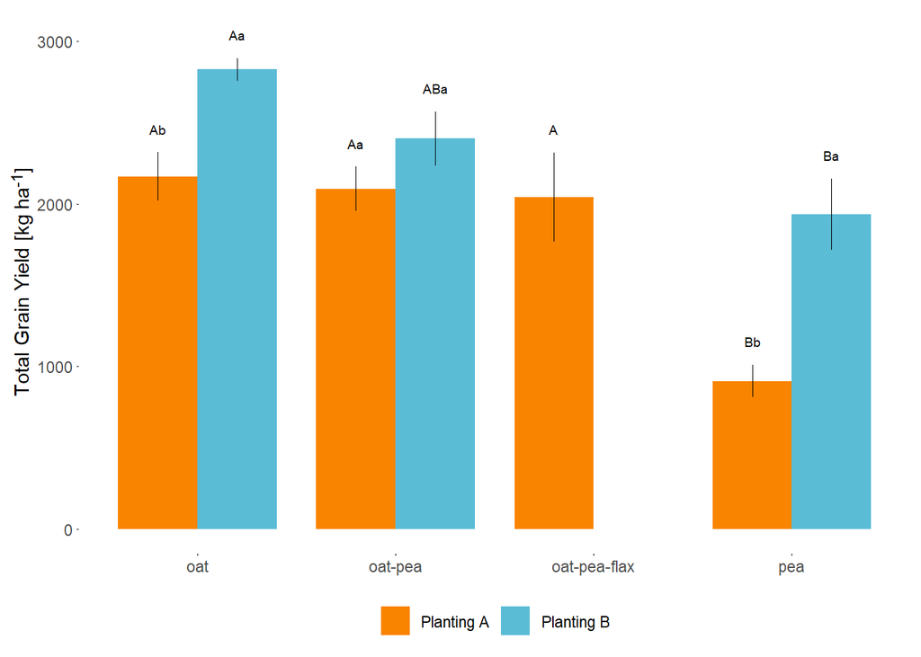

```r
dodger = position_dodge(width=0.8)

plt = ggplot(pltdf,
             aes(x=CROP,
                 y=COMBO_YIELD_HAND,
                 fill=prettyplanting)) +
  scale_fill_manual(values=colors[3:4]) +
  stat_summary(fun=mean,
               geom='bar',
               position=dodger,
               width=0.8) +
  stat_summary(fun.data=mean_se,
               geom='errorbar',
               width=0,
               position=dodger,
               linewidth=0.1) +
  geom_text(data=annotate_df,
            aes(x=CROP,
                y=Y,
                label=.group),
            size=2.5,
            position=dodger) +
  labs(x=NULL,
       y='Total Grain Yield [kg ha<sup>-1</sup>]',
       fill=NULL)
plt %<>% gg_formatter()
plt
```

Exact means and standard errors are:

```r
get_mean_se(paste(resp, pred, sep='~') %>% formula,
            data=df)
```

| CROP | PLANTING | COMBO_YIELD_HAND.MEAN | COMBO_YIELD_HAND.SE |
| --- | --- | --- | --- |
| oat | early | 2168.7992 | 147.99082 |
| oat-pea | early | 2092.1916 | 136.30524 |
| oat-pea-flax | early | 2041.0105 | 274.43731 |
| pea | early | 910.5971 | 98.84221 |
| oat | late | 2827.2638 | 69.32458 |
| oat-pea | late | 2401.7388 | 167.16931 |
| pea | late | 1935.8596 | 218.53405 |

### Format for Export

```r
fig2_data = list()
fig2_annotate = list()

annotate_df$RESP=resp
pltdf$RESP = resp
names(pltdf) %<>% gsub(resp, 'Y', .)

fig2_data[[resp]] = pltdf
fig2_annotate[[resp]] = annotate_df
```

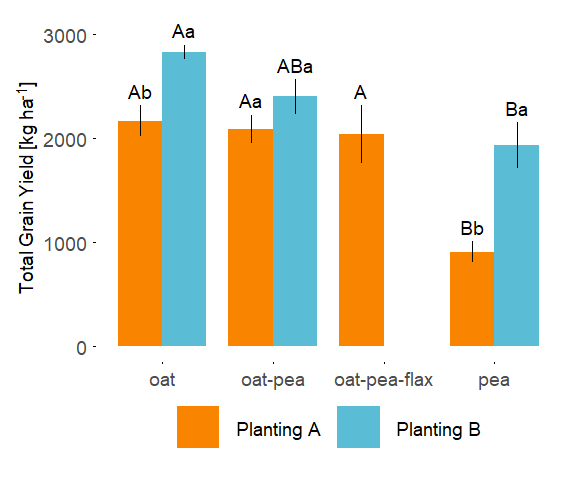

```r
fig2_yield = text_sizer(plt)
fig2_yield
```

## Total Biomass

```r
resp = 'COMBO_BIOMASS_MATURITY'
pred = 'CROP*PLANTING'
err = '(1|REP/PLANTING)'
dd = subset(df, CROP != 'oat-pea-flax')

ff = paste(resp, '~', pred, '+', err) %>%
  formula

mod = lmer(ff, data=df)
av = Anova(mod, test.statistic='F')
av
```

|  | F | Df | Df.res | Pr(>F) |
| --- | --- | --- | --- | --- |
| CROP | 12.1991767 | 3 | 15.042118 | 0.000261741 |
| PLANTING | 30.9107021 | 1 | 3.568939 | 0.007126826 |
| CROP:PLANTING | 0.5083516 | 2 | 15.042118 | 0.611458218 |

No interaction between crop and planting date. Crop has a main effect, as does planting.

Save into an anova table for the manuscript.

```r
anova_table = make_anova_table(av, append_to=anova_table)
```

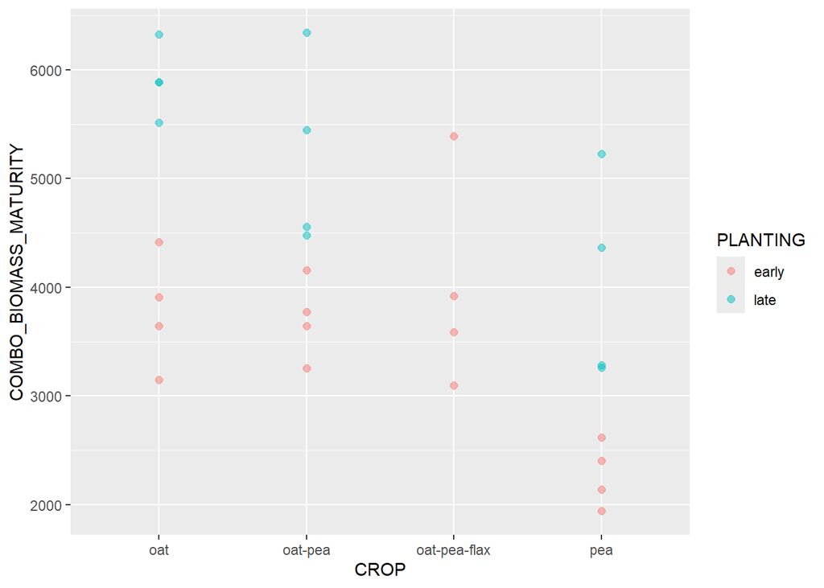

```r
ggplot(df,
       aes(x=CROP,
           y=.data[[resp]],
           color=PLANTING)) +
  geom_point(alpha=0.5,
             size=2)
```

```r
emeans = emmeans(mod, ~PLANTING | CROP) %>%
  cld(Letters=letters,
      reverse=TRUE, adjust=p_adjust)
emeans
```

|  | PLANTING | CROP | emmean | SE | df | lower.CL | upper.CL | .group |
| --- | --- | --- | --- | --- | --- | --- | --- | --- |
| 1 | late | oat | 5903.707 | 341.3037 | 19.56372 | 5075.199 | 6732.216 | a |
| 2 | early | oat | 3781.332 | 341.3037 | 19.56372 | 2952.824 | 4609.840 | b |
| 3 | late | oat-pea | 5206.857 | 341.3037 | 19.56372 | 4378.349 | 6035.365 | a |
| 4 | early | oat-pea | 3708.825 | 341.3037 | 19.56372 | 2880.317 | 4537.334 | b |
| 5 | late | oat-pea-flax | NA | NA | NA | NA | NA |  |
| 6 | early | oat-pea-flax | 3999.016 | 341.3037 | 19.56372 | 3286.050 | 4711.982 | a |
| 7 | late | pea | 4034.285 | 341.3037 | 19.56372 | 3205.777 | 4862.793 | a |
| 8 | early | pea | 2276.739 | 341.3037 | 19.56372 | 1448.231 | 3105.247 | b |

```r
emeans1 = emmeans(mod, ~CROP | PLANTING) %>%
  cld(Letters=LETTERS,
      reverse=TRUE, adjust=p_adjust)
colnames(emeans1) %<>% gsub('.group', '.GROUP', .)

emeans1
```

|  | CROP | PLANTING | emmean | SE | df | lower.CL | upper.CL | .GROUP |
| --- | --- | --- | --- | --- | --- | --- | --- | --- |
| 4 | oat-pea-flax | early | 3999.016 | 341.3037 | 19.56372 | 3060.301 | 4937.731 | A |
| 2 | oat | early | 3781.332 | 341.3037 | 19.56372 | 2842.617 | 4720.047 | A |
| 1 | oat-pea | early | 3708.825 | 341.3037 | 19.56372 | 2770.110 | 4647.541 | A |
| 3 | pea | early | 2276.739 | 341.3037 | 19.56372 | 1338.024 | 3215.454 | B |
| 8 | oat-pea-flax | late | NA | NA | NA | NA | NA |  |
| 6 | oat | late | 5903.707 | 341.3037 | 19.56372 | 5010.216 | 6797.199 | A |
| 5 | oat-pea | late | 5206.857 | 341.3037 | 19.56372 | 4313.366 | 6100.348 | A |
| 7 | pea | late | 4034.285 | 341.3037 | 19.56372 | 3140.794 | 4927.776 | B |

### Plot

```r
keep = c('PLANTING', 'CROP', '.group')

has_flax = grepl('flax', emeans$CROP)
emeans[has_flax, '.group'] = ''

emeans %<>%
  .[, keep] %>%
  merge(emeans1)

emeans[, '.group'] = with(emeans,
                          paste0(trimws(.GROUP),
                                 trimws(.group)))
```

```r
prettyplanting = c(early = 'Planting A',
                   late = 'Planting B')

annotate_df = c('CROP', 'PLANTING') %>%
  df[, .] %>%
  unique %>%
  merge(emeans,
        all.y=TRUE)
annotate_df$.group %<>% trimws()

grpY = group_Y(resp, grp, data=df)
annotate_df %<>% merge(grpY, all.x=TRUE)

pltdf = c('CROP', 'PLANTING', resp) %>%
  df[, .]
late_flax = data.frame(CROP='oat-pea-flax' %>%
                 factor(levels=levels(df$CROP)),
               PLANTING='late' %>%
                 factor(levels=levels(df$PLANTING)),
               x=0) %>%
  set_names(names(pltdf))
pltdf %<>% rbind(late_flax)

pltdf$prettyplanting = pltdf$PLANTING %>%
  as.character %>%
  prettyplanting[.]
annotate_df$prettyplanting = annotate_df$PLANTING %>%
  as.character %>%
  prettyplanting[.]
```

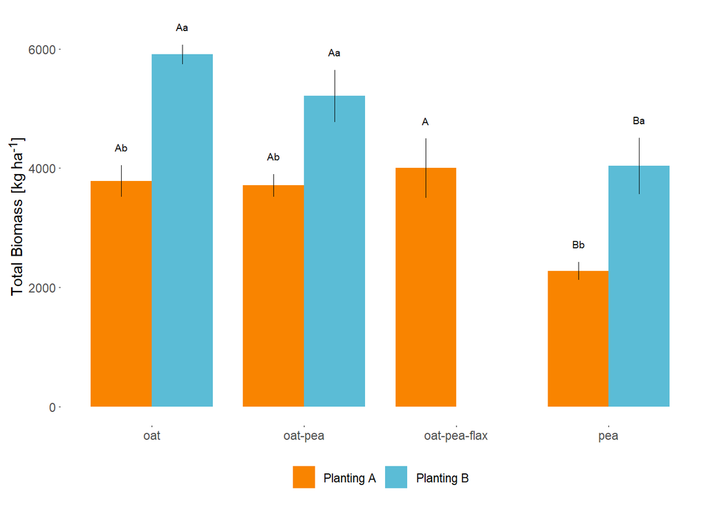

```r
dodger = position_dodge(width=0.8)

plt = ggplot(pltdf,
             aes(x=CROP,
                 y=.data[[resp]],
                 fill=prettyplanting)) +
  scale_fill_manual(values=colors[3:4]) +
  stat_summary(fun=mean,
               geom='bar',
               position=dodger,
               width=0.8) +
  stat_summary(fun.data=mean_se,
               geom='errorbar',
               width=0,
               position=dodger,
               linewidth=0.1) +
  geom_text(data=annotate_df,
            aes(x=CROP,
                y=Y,
                label=.group),
            size=2.5,
            position=dodger) +
  labs(x=NULL,
       y='Total Biomass [kg ha<sup>-1</sup>]',
       fill=NULL)
plt %<>% gg_formatter

plt
```

Exact means and standard errors are:

```r
get_mean_se(paste(resp, pred, sep='~') %>% formula,
            data=df)
```

| CROP | PLANTING | COMBO_BIOMASS_MATURITY.MEAN | COMBO_BIOMASS_MATURITY.SE |
| --- | --- | --- | --- |
| oat | early | 3781.332 | 264.2399 |
| oat-pea | early | 3708.825 | 186.0309 |
| oat-pea-flax | early | 3999.016 | 493.9820 |
| pea | early | 2276.739 | 149.1589 |
| oat | late | 5903.707 | 165.4247 |
| oat-pea | late | 5206.857 | 437.9629 |
| pea | late | 4034.285 | 474.5559 |

### Format for Export

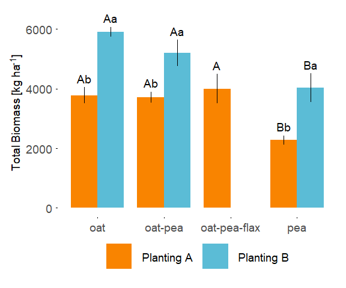

```r
annotate_df$RESP=resp
annotate_df$prettyplanting %<>% gsub('Planting ', '', .)
pltdf$RESP = resp
pltdf$prettyplanting %<>% gsub('Planting ', '', .)
names(pltdf) %<>% gsub(resp, 'Y', .)

fig2_data[[resp]] = pltdf
fig2_annotate[[resp]] = annotate_df

fig2_biomass = text_sizer(plt)
fig2_biomass
```

## Plotted Land Equivalent Ratios

```r
means_df = subset(df, CROP %in% c('oat', 'pea'))
oat_means = aggregate(OAT_YIELD_HAND ~ PLANTING + CROP, data=means_df, mean)
pea_means = aggregate(PEA_YIELD_HAND ~ PLANTING + CROP, data=means_df, mean)
means_df = merge(oat_means, pea_means)
means_df %<>% rbind(
  data.frame(
    PLANTING = c('early', 'late') %>%
      factor(levels=levels(means_df$PLANTING)),
    CROP = c(NA, NA),
    OAT_YIELD_HAND= c(0, 0),
    PEA_YIELD_HAND = c(0, 0)
  )
)

annotate_df = data.frame(
  PLANTING = c('early', 'early', 'late', 'late'),
  x = c(350, 1800, 500, 2000),
  y = c(50, 1000, 100, 2100),
  LABEL = c('LER < 1', 'LER > 1', 'LER < 1', 'LER > 1')
)

means_df$prettyplanting = means_df$PLANTING %>%
  as.character %>%
  prettyplanting[.]

annotate_df$prettyplanting = annotate_df$PLANTING %>%
  prettyplanting[.]

df$prettyplanting = df$PLANTING %>%
  as.character %>%
  prettyplanting[.]
```

```r
plt = ggplot(df,
       aes(x=OAT_YIELD_HAND,
           y=PEA_YIELD_HAND,
           color=CROP,
           shape=CROP)) +
  scale_color_manual(values=colors) +
  scale_shape_manual(values=c(18, 17, 15, 16)) +
  facet_wrap(~prettyplanting, scales='free') +
  geom_polygon(data=means_df,
            aes(x=OAT_YIELD_HAND,
                y=PEA_YIELD_HAND),
            inherit.aes=FALSE,
            fill='lightgray',
            color=NA) +
  geom_point(size=1.5,
             alpha=0.7) +
  geom_text(data=annotate_df,
             aes(x=x,
                 y=y,
                 label=LABEL),
            size=2.5,
            inherit.aes=FALSE) +
  labs(x='Oat Yield [kg ha<sup>-1</sup>]',
       y='Pea Yield [kg ha<sup>-1</sup>]',
       color=NULL,
       shape=NULL) +
  theme_minimal()
plt %<>% gg_formatter()
```

scatterplot approach. Points above the line are overyielding. So the early planting date overyielded.

### Format for export

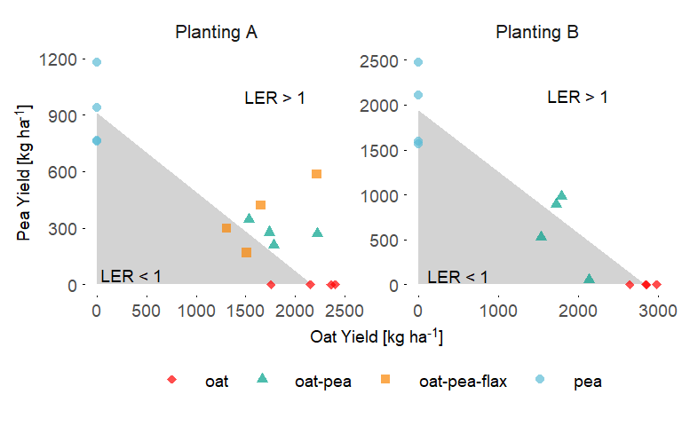

```r
fig2_LER = text_sizer(plt)
fig2_LER
```

## Calculated LER

LER = sum(y_poly/y_mono)

```r
yieldnames = c('OAT', 'PEA') %>%
  paste0('_YIELD_HAND')

cols = c('REP', 'PLANTING', 'CROP', yieldnames)

ler = df[, cols] %>%
  subset(CROP != 'oat-pea-flax')

ler = pivot_wider(ler,
                  names_from='CROP',
                  values_from=all_of(yieldnames))

ler$OAT_FRAC = with(ler, `OAT_YIELD_HAND_oat-pea`/`OAT_YIELD_HAND_oat`)
ler$PEA_FRAC = with(ler, `PEA_YIELD_HAND_oat-pea`/`PEA_YIELD_HAND_pea`)
ler$LER = with(ler, OAT_FRAC + PEA_FRAC)
```

```r
to_drop = grepl('YIELD_HAND', colnames(ler))
ler %<>% .[, !to_drop]
```

```r
resp = 'LER'
pred = 'PLANTING'
err = '(1|REP)'

ff = paste(resp, '~', pred, '+', err) %>%
  formula

mod = lmer(ff, data=ler)
av = Anova(mod, test.statistic='F')
av
```

|  | F | Df | Df.res | Pr(>F) |
| --- | --- | --- | --- | --- |
| PLANTING | 2.640623 | 1 | 3 | 0.2026308 |

No difference in LER across planting dates.

Save into an anova table for the manuscript.

```r
anova_table = make_anova_table(av, append_to=anova_table)
```

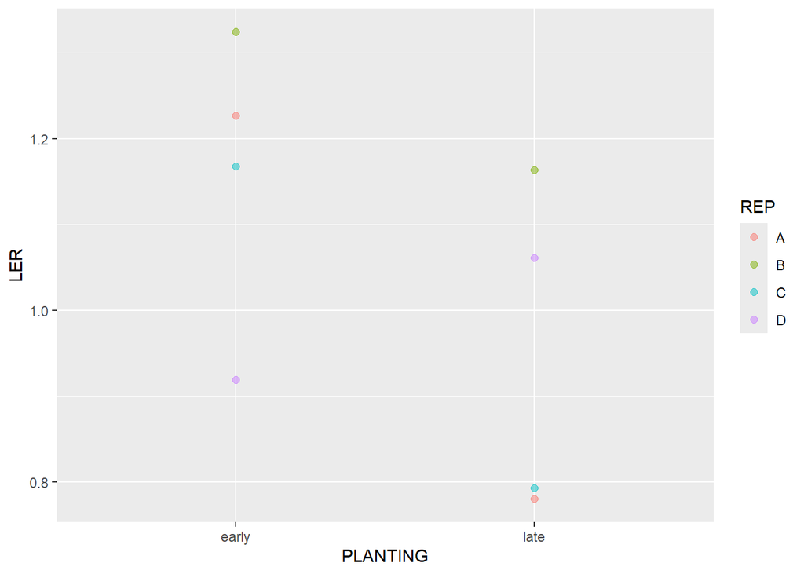

```r
ggplot(ler,
       aes(x=PLANTING,
           y=.data[[resp]],
           color=REP)) +
  geom_point(alpha=0.5,
             size=2)
```

```r
with(ler, tapply(LER, PLANTING, t.test, mu=1))
```

```
## $early
##
##  One Sample t-test
##
## data:  X[[i]]
## t = 1.8503, df = 3, p-value = 0.1614
## alternative hypothesis: true mean is not equal to 1
## 95 percent confidence interval:
##  0.8849024 1.4348484
## sample estimates:
## mean of x
##  1.159875
##
##
## $late
##
##  One Sample t-test
##
## data:  X[[i]]
## t = -0.52363, df = 3, p-value = 0.6368
## alternative hypothesis: true mean is not equal to 1
## 95 percent confidence interval:
##  0.6427853 1.2562724
## sample estimates:
## mean of x
## 0.9495289
```

On average LER no different from 1, surprisingly. In the early planting date it was a small increase and noise was such that we didn’t see any strong differences.

Exact means and standard errors are:

```r
get_mean_se(paste(resp, pred, sep='~') %>% formula,
            data=ler)
```

| PLANTING | LER.MEAN | LER.SE |
| --- | --- | --- |
| early | 1.1598754 | 0.08640303 |
| late | 0.9495289 | 0.09638609 |

### Figure 2 - yield and LER

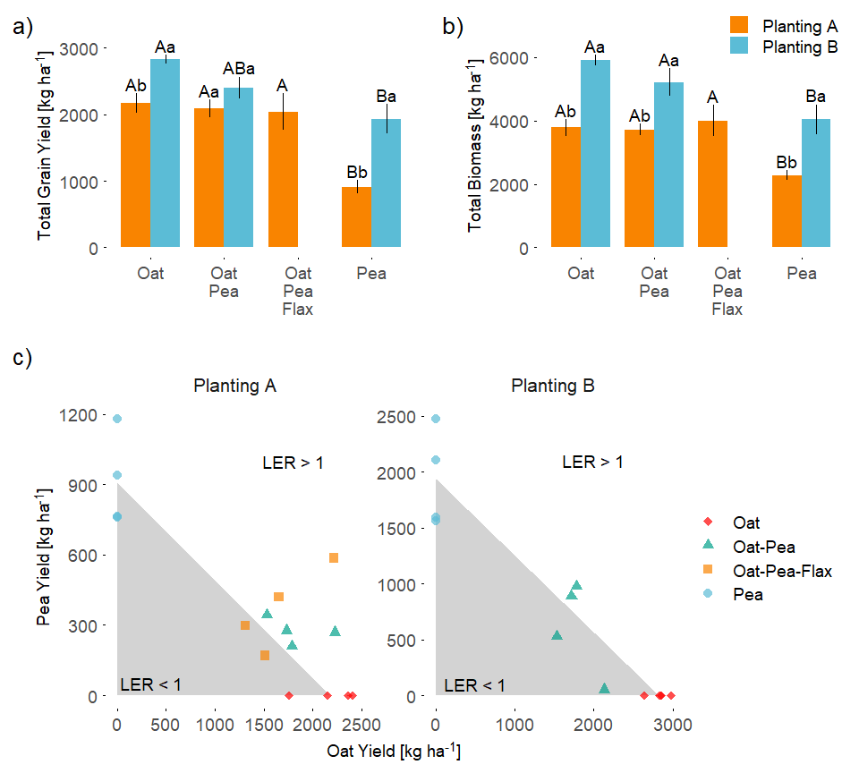

```r
xlabs = c('oat' = 'Oat',
          'oat-pea' = 'Oat\nPea',
          'oat-pea-flax' = 'Oat\nPea\nFlax',
          'pea' = 'Pea')

collabs = c('oat' = 'Oat',
          'oat-pea' = 'Oat-Pea',
          'oat-pea-flax' = 'Oat-Pea-Flax',
          'pea' = 'Pea')

p1 = fig2_yield +
  scale_x_discrete(labels=xlabs) +
  labs(tag='a)') +
  theme(legend.position='none')
p2 = fig2_biomass +
  scale_x_discrete(labels=xlabs) +
  labs(tag='b)') +
  theme(legend.position=c(0.8, 1),
        legend.key.size=unit(0.12, 'in'),
        legend.title=element_text(size=8),
        axis.ticks=element_line(color='black', linewidth=0.1),
        axis.ticks.length=unit(0.3, units='mm'))
p3 = fig2_LER +
  labs(tag='c)') +
  scale_color_manual(values=colors,
                     labels=collabs) +
  scale_shape_manual(values=c(18, 17, 15, 16),
                     labels=collabs) +
  theme(legend.position='right',
        legend.key.size=unit(0.14, 'in'))
marrangeGrob(grobs=list(p1, p2, p3),
             layout_matrix=matrix(c(1,2,
                                    1,2,
                                    1,2,
                                    3,3,
                                    3,3,
                                    3,3,
                                    3,3),
                                  nrow=7,
                                  byrow=TRUE),
             top=NULL)
```

### Export

```r
here(out_dir,
     'Figure 2 - Yield and LER.jpg') %>%
  jpeg(width=5, height=4.5, units='in', res=300)

marrangeGrob(grobs=list(p1, p2, p3),
             layout_matrix=matrix(c(1,2,
                                    3,3),
                                  nrow=2,
                                  byrow=TRUE),
             top=NULL)
```

```r
dev.off()
```

## Stability

As differences in yield between planting dates

```r
keep_cols = c('REP', 'PLANTING', 'CROP', 'COMBO_YIELD_HAND')
dif = subset(df, CROP != 'oat-pea-flax', select=keep_cols) %>%
  pivot_wider(names_from='PLANTING',
              values_from='COMBO_YIELD_HAND')
dif$DIF = with(dif, late - early)
```

```r
ttest = tapply(dif$DIF, dif$CROP, t.test) %>%
  sapply('[[', c('p.value'))
ttest
```

```
## $oat
## [1] 0.01894229
##
## $`oat-pea`
## [1] 0.3263896
##
## $`oat-pea-flax`
## NULL
##
## $pea
## [1] 0.02273904
```

oat and pea yields differed across planting dates, while oat-pea yield was not different.

```r
tt = get_mean_se(DIF ~ CROP, data=dif)
tt
```

| CROP | DIF.MEAN | DIF.SE |
| --- | --- | --- |
| oat | 658.4646 | 142.1227 |
| oat-pea | 309.5472 | 264.5017 |
| pea | 1025.2625 | 236.8728 |

Oat and pea yields were higher in the late planting than the early. Oat-pea was not significantly different between plantings.

### Plot Fig 3 - Stability

```r
resp='DIF'
prettyplanting = c(early = 'Planting A',
                   late = 'Planting B')

grp = 'CROP'


ttest %<>% sapply(function(x) ifelse(x<0.05, '*', 'n.s.')) %>%
  unlist(recursive=FALSE)
annotate_df = c('CROP') %>%
  dif[, .] %>%
  unique
annotate_df$.group = ttest[as.character(annotate_df$CROP)]

grpY = group_Y(resp, grp, data=dif)
annotate_df %<>% merge(grpY, all.x=TRUE)


pltdf = dif
```

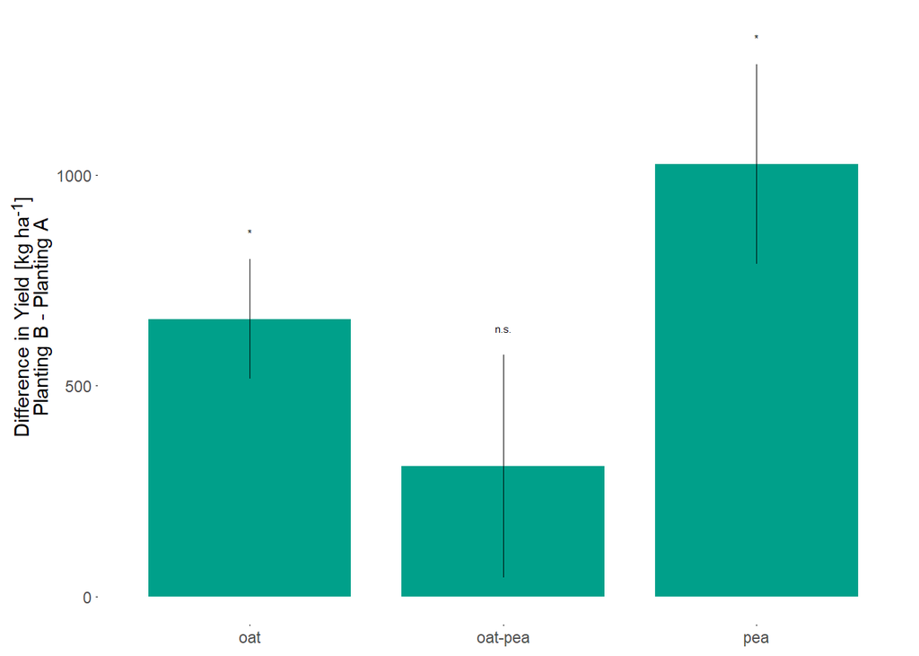

```r
dodger = position_dodge(width=0.8)

plt = ggplot(pltdf,
             aes(x=CROP,
                 y=.data[[resp]])) +
  scale_fill_manual(values=colors[3:4]) +
  stat_summary(fun=mean,
               geom='bar',
               position=dodger,
               width=0.8,
               fill=colors[2]) +
  stat_summary(fun.data=mean_se,
               geom='errorbar',
               width=0,
               position=dodger,
               linewidth=0.1) +
  geom_text(data=annotate_df,
            aes(x=CROP,
                y=Y,
                label=.group),
            size=2,
            position=dodger) +
  labs(x=NULL,
       y='Difference in Yield [kg ha<sup>-1</sup>]<br>Planting B - Planting A',
       fill=NULL)
plt %<>% gg_formatter

plt
```

### Format for export

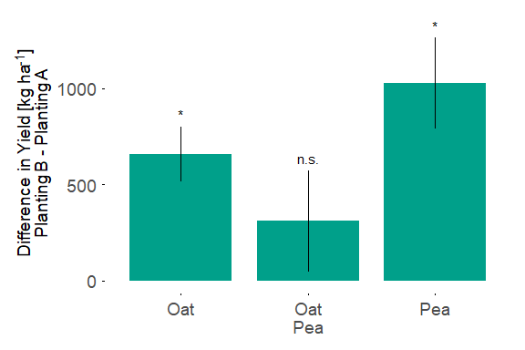

```r
xlabs = c('oat' = 'Oat',
          'oat-pea' = 'Oat\nPea',
          'oat-pea-flax' = 'Oat\nPea\nFlax',
          'pea' = 'Pea')
fig3 = text_sizer(plt, 8)
fig3 = fig3 +
  scale_x_discrete(labels=xlabs)
fig3
```

```r
here(out_dir,
     'Figure 3 - Stability.jpeg') %>%
  jpeg(width=3, height=2, units='in', res=300)
fig3
dev.off()
```

# Individual crop yields

## Oat

```r
resp = 'OAT_YIELD_HAND'
pred = 'CROP*PLANTING'
err = '(1|REP/PLANTING)'
dd = subset(df, CROP != 'oat-pea-flax')

ff = paste(resp, '~', pred, '+', err) %>%
  formula

mod = lmer(ff, data=df)
av = Anova(mod, test.statistic='F')
av
```

|  | F | Df | Df.res | Pr(>F) |
| --- | --- | --- | --- | --- |
| CROP | 260.058156 | 3 | 15.018932 | 3.650142e-13 |
| PLANTING | 6.571809 | 1 | 3.771192 | 6.610233e-02 |
| CROP:PLANTING | 8.719552 | 2 | 15.018932 | 3.066960e-03 |

For oats, A marginal planting date effect. Most is an interaction between mix and planting date.

Save into an anova table for the manuscript.

```r
anova_table = make_anova_table(av, append_to=anova_table)
```

```r
get_mean_se(paste(resp, pred, sep='~') %>% formula,
            data=df)
```

| CROP | PLANTING | OAT_YIELD_HAND.MEAN | OAT_YIELD_HAND.SE |
| --- | --- | --- | --- |
| oat | early | 2168.799 | 147.99082 |
| oat-pea | early | 1816.929 | 145.74095 |
| oat-pea-flax | early | 1672.408 | 195.14524 |
| pea | early | 0.000 | 0.00000 |
| oat | late | 2827.264 | 69.32458 |
| oat-pea | late | 1790.190 | 124.49865 |
| pea | late | 0.000 | 0.00000 |

```r
emeans = emmeans(mod, ~CROP | PLANTING) %>%
  cld(Letters=letters,
      reverse=TRUE,
      adjust=p_adjust)
emeans
```

|  | CROP | PLANTING | emmean | SE | df | lower.CL | upper.CL | .group |
| --- | --- | --- | --- | --- | --- | --- | --- | --- |
| 4 | oat | early | 2.168799e+03 | 120.0599 | 11.21085 | 1812.1869 | 2525.4115 | a |
| 3 | oat-pea | early | 1.816929e+03 | 120.0599 | 11.21085 | 1460.3168 | 2173.5415 | b |
| 2 | oat-pea-flax | early | 1.672408e+03 | 120.0599 | 11.21085 | 1315.7958 | 2029.0205 | b |
| 1 | pea | early | 2.273737e-12 | 120.0599 | 11.21085 | -356.6123 | 356.6123 | c |
| 8 | oat-pea-flax | late | NA | NA | NA | NA | NA |  |
| 6 | oat | late | 2.827264e+03 | 120.0599 | 11.21085 | 2489.8007 | 3164.7268 | a |
| 5 | oat-pea | late | 1.790190e+03 | 120.0599 | 11.21085 | 1452.7272 | 2127.6533 | b |
| 7 | pea | late | 2.160050e-12 | 120.0599 | 11.21085 | -337.4631 | 337.4631 | c |

## Pea

```r
resp = 'PEA_YIELD_HAND'
pred = 'CROP*PLANTING'
err = '(1|REP/PLANTING)'
dd = subset(df, CROP != 'oat-pea-flax')

ff = paste(resp, '~', pred, '+', err) %>%
  formula

mod = lmer(ff, data=df)
av = Anova(mod, test.statistic='F')
av
```

|  | F | Df | Df.res | Pr(>F) |
| --- | --- | --- | --- | --- |
| CROP | 50.759277 | 3 | 15.056072 | 4.170396e-08 |
| PLANTING | 15.702585 | 1 | 3.669842 | 1.965263e-02 |
| CROP:PLANTING | 9.800934 | 2 | 15.056072 | 1.880033e-03 |

Save into an anova table for the manuscript.

```r
anova_table = make_anova_table(av, append_to=anova_table)
```

```r
get_mean_se(paste(resp, pred, sep='~') %>% formula,
            data=df)
```

| CROP | PLANTING | PEA_YIELD_HAND.MEAN | PEA_YIELD_HAND.SE |
| --- | --- | --- | --- |
| oat | early | 0.0000 | 0.00000 |
| oat-pea | early | 275.2625 | 27.67015 |
| oat-pea-flax | early | 368.6024 | 88.88044 |
| pea | early | 910.5971 | 98.84221 |
| oat | late | 0.0000 | 0.00000 |
| oat-pea | late | 611.5486 | 210.31847 |
| pea | late | 1935.8596 | 218.53405 |

```r
emeans = emmeans(mod, ~CROP | PLANTING) %>%
  cld(Letters=letters,
      reverse=TRUE,
      adjust=p_adjust)
emeans
```

|  | CROP | PLANTING | emmean | SE | df | lower.CL | upper.CL | .group |
| --- | --- | --- | --- | --- | --- | --- | --- | --- |
| 1 | pea | early | 9.105971e+02 | 125.8925 | 20.24321 | 565.50665 | 1255.6876 | a |
| 2 | oat-pea-flax | early | 3.686024e+02 | 125.8925 | 20.24321 | 23.51190 | 713.6928 | b |
| 3 | oat-pea | early | 2.752625e+02 | 125.8925 | 20.24321 | -69.82799 | 620.3529 | b |
| 4 | oat | early | 6.288457e-13 | 125.8925 | 20.24321 | -345.09046 | 345.0905 | b |
| 5 | oat-pea-flax | late | NA | NA | NA | NA | NA |  |
| 6 | pea | late | 1.935860e+03 | 125.8925 | 20.24321 | 1607.31249 | 2264.4067 | a |
| 8 | oat-pea | late | 6.115486e+02 | 125.8925 | 20.24321 | 283.00146 | 940.0957 | b |
| 7 | oat | late | -2.535621e-13 | 125.8925 | 20.24321 | -328.54709 | 328.5471 | c |

## Plot

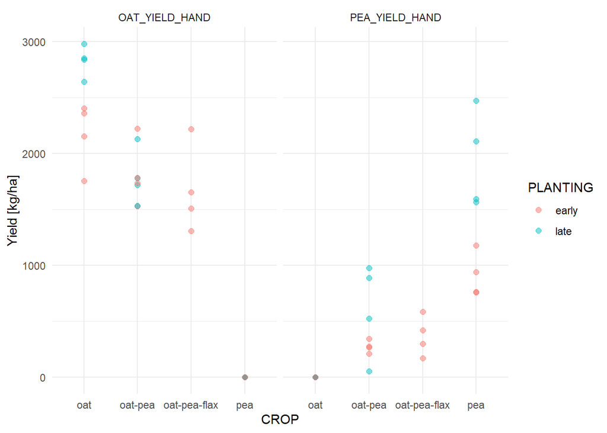

```r
pltdf = df[, c('CROP', 'PLANTING', 'OAT_YIELD_HAND', 'PEA_YIELD_HAND')] %>%
  pivot_longer(cols=where('is.numeric'))
ggplot(pltdf,
       aes(x=CROP,
           y=value,
           color=PLANTING)) +
  facet_wrap(~name) +
  geom_point(alpha=0.5,
             size=2) +
  labs(y='Yield [kg/ha]') +
  theme_minimal()
```

In the mix, pea did better at the later planting date, while oats did slightly better at the earlier planting date.

# Quality

## Grain ratios

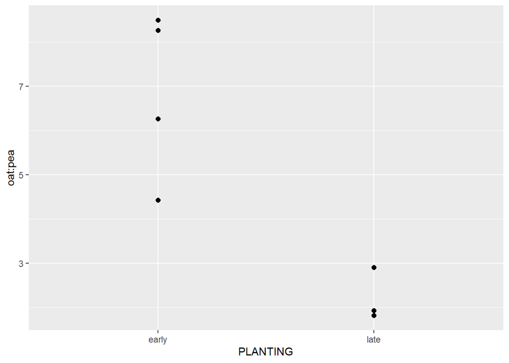

```r
ratios = subset(df, CROP=='oat-pea')
ratios$RATIO = with(ratios, OAT_YIELD_HAND/PEA_YIELD_HAND)
ratios = ratios[-c(2), ]

ggplot(ratios,
       aes(x=PLANTING,
           y=RATIO)) +
  geom_point(size=2) +
  ylab("oat:pea")
```

```r
mod = lmer(RATIO ~ PLANTING + (1|REP), data=ratios)
```

```
## boundary (singular) fit: see help('isSingular')
```

```r
av = Anova(mod, test.statistic='F')
av
```

|  | F | Df | Df.res | Pr(>F) |
| --- | --- | --- | --- | --- |
| PLANTING | 13.92329 | 1 | 2.606383 | 0.04249653 |

Save into an anova table for the manuscript.

```r
anova_table = make_anova_table(av, append_to=anova_table)
```

```r
emeans = emmeans(mod, ~PLANTING) %>%
  cld(Letters=LETTERS, reverse=TRUE)
emeans
```

|  | PLANTING | emmean | SE | df | lower.CL | upper.CL | .group |
| --- | --- | --- | --- | --- | --- | --- | --- |
| 2 | early | 6.860463 | 0.7613770 | 5 | 4.9032813 | 8.817645 | A |
| 1 | late | 2.221136 | 0.9829334 | 5 | -0.3055746 | 4.747847 | B |

```r
annotate_df = emeans %>%
  as.data.frame
annotate_df$.group %<>% trimws()
annotate_df$Y = 0.5

pltdf = c('RATIO', 'PLANTING') %>%
  ratios[, .]
pltdf$prettyplanting = pltdf$PLANTING %>%
  as.character %>%
  prettyplanting[.]
```

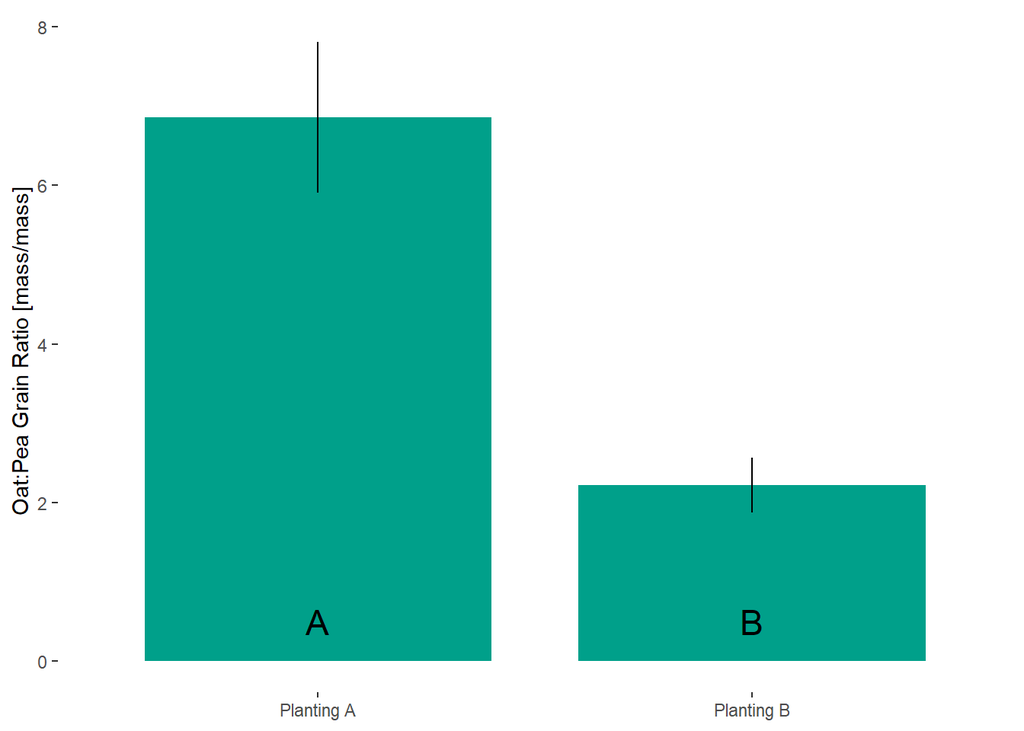

```r
plt = ggplot(pltdf,
             aes(x=prettyplanting,
                 y=RATIO)) +
  # scale_fill_manual(values=colors[3:4]) +
  stat_summary(fun=mean,
               geom='bar',
               position=dodger,
               width=0.8,
               fill=colors[2]) +
  stat_summary(fun.data=mean_se,
               geom='errorbar',
               width=0,
               position=dodger) +
  geom_text(data=annotate_df,
            aes(x=prettyplanting,
                y=Y,
                label=.group),
            inherit.aes=FALSE,
            size=6,
            position=dodger) +
  labs(x=NULL,
       y='Oat:Pea Grain Ratio [mass/mass]',
       fill=NULL) +
  theme(panel.background=element_blank(),
        legend.position='bottom')

plt
```

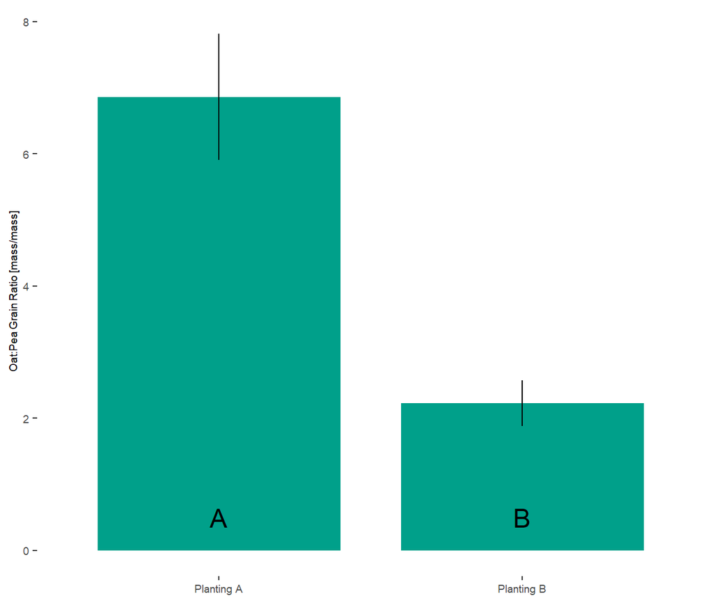

```r
plt = text_sizer(plt)
plt
```

```r
here('Results', 'Grain Ratios.jpg') %>%
  jpeg(height=5.5, width=6.5, units='in', res=300)
plt
dev.off()
```